# Midterm Project:

## Determinants of County-Level Health Outcomes: A Data Analysis of Poor Health in U.S. Counties

Bell Dai

```python
import os
import pandas as pd
import seaborn as sns
import numpy as np
import matplotlib.pyplot as plt

os.chdir('/Users/bella/Desktop')
county_data = pd.read_csv("midterm_project.csv",index_col='Row.Label')
y = county_data['Poor.Health']
```

# 1 Dataset Introduction

Currently, counties in the US are developing at a surging rate. As the national income goes up, citizens are seeking higher living standards and focusing more on their physical and mental health. Thus, it is crucial to discover what factors have an impact on the citizens'health.

- The data concerns health, economic, and demographic characteristics measured at the county level in the US.
- The unit of analysis is the county.
- We are interested in investigating the relationship between different predictors and the health index.

# 2 Goal

- Health outcomes vary widely across communities, often reflecting differences in lifestyle, economic conditions, and access to care. This study examines how factors like smoking, unemployment, insurance coverage, and healthcare access shape these disparities.
- By identifying the most important predictors, the findings can guide targeted policies.
- E.g., Smoking prevention programs or expanding insurance coverage: to reduce health inequalities and improve overall population health.

# 3 Four Possible questions

## Based on the dataset and our research goals, there are four questions that I am intrigued to investigate:

- Are the health indices negatively correlated with the unemployment rates in each county?
- Is excessive drinking associated with poor health outcomes across counties?
- Are counties with both high smoking and high uninsured rates more likely to have worse health outcomes?
- Do counties with fewer primary care physicians and higher uninsured rates experience worse health outcomes?

# 4 Summary Statistics

According to the research questions, the variables that we will focus on are:

- X(Predictors):
  - Unemployment:County-wide Unemployment rate
  - Excessive.Drinking: Proportion of population involved in excessive drinking
  - Uninsured: Proportion of the county that does not havehealth insurance
  - Proportion.of.Smokers: Proportion of smokers in the county
  - Primary.Care.Physicians.Per.1000: Number of providers in the county per 1000 people
- Y(response):
  - Poor.Health: Proportion of the county that has poor health status

# 5 Description of the Dataset

```python
county_data.columns
```

```
Index(['Five-digit.FIPS.Code', 'State.FIPS.Code', 'County.FIPS.Code',
       'State.Abbreviation', 'CountyName', 'Poor.Health',
       'Election.Results.2016', 'Uninsured',
       'Primary.Care.Physicians.Per.1000', 'Mental.health.providers.Per.1000',
       'Adult.Obesity', 'Proportion.of.Smokers', 'High.School.Graduation',
       'Insufficient.Sleep', 'Physical.Inactivity', 'Excessive.Drinking',
       'Median.Household.Income', 'Severe.Housing.Problems', 'Unemployment',
       'Food.Insecurity.Quintile', 'Income.Inequality.Quartile',
       'Percent.Rural', 'Over.65', 'Percent.Females', 'Life.Expectancy',
       'Population'],
      dtype='object')
```

```python
print(county_data.shape)
print(county_data.describe())
```

```
(2715, 26)
       Five-digit.FIPS.Code  State.FIPS.Code  County.FIPS.Code  Poor.Health  \
count           2715.000000      2715.000000       2715.000000  2715.000000
mean           30479.473665        30.376059        103.414733     0.174385
std            15292.329045        15.272748        108.697370     0.045176
min             1001.000000         1.000000          1.000000     0.082900
25%            19016.000000        19.000000         35.000000     0.140350
50%            29163.000000        29.000000         79.000000     0.167300
75%            46025.000000        46.000000        133.000000     0.203950
max            56045.000000        56.000000        840.000000     0.407300

         Uninsured  Primary.Care.Physicians.Per.1000  \
count  2715.000000                       2715.000000
mean      0.107790                          0.557937
std       0.047841                          0.329909
min       0.020700                          0.000000
25%       0.069200                          0.337500
50%       0.100700                          0.500000
75%       0.134650                          0.722000
max       0.308800                          4.470000

       Mental.health.providers.Per.1000  Adult.Obesity  Proportion.of.Smokers  \
count                       2715.000000    2715.000000            2715.000000
mean                           1.486268       0.320086               0.178243
std                            1.499236       0.045581               0.034748
min                            0.042000       0.138000               0.067354
25%                            0.474500       0.294000               0.152513
50%                            1.036000       0.323000               0.173543
75%                            1.992000       0.350000               0.202849
max                           15.579000       0.495000               0.331744

       High.School.Graduation  ...  Physical.Inactivity  Excessive.Drinking  \
count             2715.000000  ...          2715.000000         2715.000000
mean                 0.882899  ...             0.255718            0.174894
std                  0.070744  ...             0.051730            0.031926
min                  0.363000  ...             0.084000            0.092652
25%                  0.846900  ...             0.221000            0.152109
50%                  0.894500  ...             0.256000            0.174272
75%                  0.933600  ...             0.291000            0.196637
max                  1.000000  ...             0.451000            0.294401
```

[output cut: 17 more lines]

```
50%         0.545000     0.182000         0.504000        77.544959
75%         0.777600     0.210000         0.511000        79.232825
max         1.000000     0.569000         0.570000        97.965235

         Population
count  2.715000e+03
mean   1.181631e+05
std    3.560418e+05
min    1.718000e+03
25%    1.452450e+04
50%    3.159400e+04
75%    8.273800e+04
max    1.016351e+07

[8 rows x 21 columns]
```

```python
county_data.head(2)
```

| Row.Label | Five-digit.FIPS.Code | State.FIPS.Code | County.FIPS.Code | State.Abbreviation | CountyName | Poor.Health | Election.Results.2016 | Uninsured | Primary.Care.Physicians.Per.1000 | Mental.health.providers.Per.1000 | ... | Median.Household.Income | Severe.Housing.Problems | Unemployment | Food.Insecurity.Quintile | Income.Inequality.Quartile | Percent.Rural | Over.65 | Percent.Females | Life.Expectancy | Population |
| --- | --- | --- | --- | --- | --- | --- | --- | --- | --- | --- | --- | --- | --- | --- | --- | --- | --- | --- | --- | --- | --- |
| AL_Autauga County | 1001 | 1 | 1 | AL | Autauga County | 0.1841 | Republican | 0.085 | 0.415 | 0.162 | ... | 58343 | 0.1495 | 0.0386 | Q3 | Q3 | 0.4200 | 0.151 | 0.513 | 76.330589 | 55504 |
| AL_Baldwin County | 1003 | 1 | 3 | AL | Baldwin County | 0.1806 | Republican | 0.107 | 0.729 | 0.912 | ... | 56607 | 0.1383 | 0.0399 | Q3 | Q3 | 0.4228 | 0.199 | 0.515 | 78.599498 | 212628 |

2 rows × 26 columns

# 6 Summary of the data around the health index

Now we can interpret from the histogram of the health index:

- The health index is roughly normally distributed across counties and slightly right-skewed.

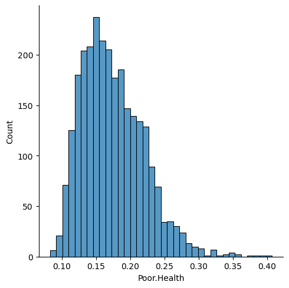

```python
plt.figure(figsize=(6,4))
sns.displot(county_data['Poor.Health'])
plt.show()
```

```python
county_data['Poor.Health'].describe()
county_data["Poor.Health"].isna().sum()
county_data[["Poor.Health", "State.Abbreviation"]].head()
```

| Row.Label | Poor.Health | State.Abbreviation |
| --- | --- | --- |
| AL_Autauga County | 0.1841 | AL |
| AL_Baldwin County | 0.1806 | AL |
| AL_Barbour County | 0.2577 | AL |
| AL_Bibb County | 0.2000 | AL |
| AL_Blount County | 0.2110 | AL |

## 6.1 The top and bottom 5 states compared by the means of their health indices

- It is also worthwhile to investigate the means of the health indices of every state to compare overall health outcomes across regions and identify patterns of inequality.
- This state-level perspective helps highlight systematic differences and potential factors, such as access to healthcare or socioeconomic conditions, that may drive variation in health outcomes.

```
The 5 states with the highest health indices are:  State.Abbreviation
AR    0.231626
AL    0.229694
WV    0.225047
MS    0.223572
KY    0.221119
Name: Poor.Health, dtype: float64
The 5 states with the lowest health indices are:  State.Abbreviation
CT    0.113317
VT    0.116242
SD    0.119667
RI    0.121780
MN    0.123187
Name: Poor.Health, dtype: float64
```

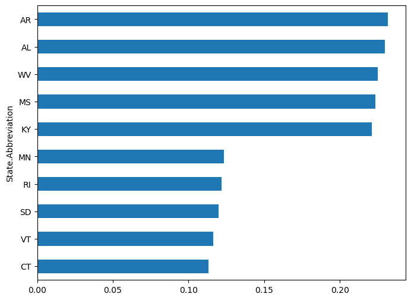

```python
state_mean = county_data.groupby("State.Abbreviation")["Poor.Health"].mean()
top_states = state_mean.sort_values(ascending = False).head()
bottom_states = state_mean.sort_values().head()
print("The 5 states with the highest health indices are: ", top_states)
print("The 5 states with the lowest health indices are: ", bottom_states)

state_extremes = pd.concat([top_states, bottom_states])
state_extremes.sort_values().plot(kind="barh", figsize=(8,6))
plt.show()
```

# 7 Association between the health index and the predictors

It is valuable for us to see if there are any correlations among predictors and between predictors and response.

```python
county_data[["Poor.Health", "Unemployment", 'Proportion.of.Smokers', 'Uninsured',
            'Excessive.Drinking', 'Primary.Care.Physicians.Per.1000']].corr()
```

|  | Poor.Health | Unemployment | Proportion.of.Smokers | Uninsured | Excessive.Drinking | Primary.Care.Physicians.Per.1000 |
| --- | --- | --- | --- | --- | --- | --- |
| Poor.Health | 1.000000 | 0.544357 | 0.723864 | 0.453265 | -0.660582 | -0.306522 |
| Unemployment | 0.544357 | 1.000000 | 0.410051 | 0.078718 | -0.355430 | -0.199171 |
| Proportion.of.Smokers | 0.723864 | 0.410051 | 1.000000 | 0.131280 | -0.484103 | -0.286754 |
| Uninsured | 0.453265 | 0.078718 | 0.131280 | 1.000000 | -0.356325 | -0.242854 |
| Excessive.Drinking | -0.660582 | -0.355430 | -0.484103 | -0.356325 | 1.000000 | 0.242944 |
| Primary.Care.Physicians.Per.1000 | -0.306522 | -0.199171 | -0.286754 | -0.242854 | 0.242944 | 1.000000 |

# 8 Important Scatterplots

While we can use tables to see correlations among variables, a scatterplot is another powerful tool for visualizing their relationships. There are several metrics that will be applied to the scatterplots below:

- If we only have one predictor (first 2 models), it is more valuable for us to conclude state-level data and compare the results at the state level. So, the points in the plots are colored by states.
- We can use a 3-D scatterplot for models that have 2 predictors (the last 2 models), but it is more interpretable to differentiate one of the predictors using different colors.

## 8.1 Unemployment rate as the only predictor

- The scatterplot shows a clear positive relationship between unemployment rates and poor health, with higher unemployment generally associated with worse health outcomes.
- Most counties cluster at lower unemployment levels, but the spread increases as unemployment rises, indicating greater variability in health outcomes.
- While there is an overall upward trend, the dispersion suggests that other factors beyond unemployment also influence poor health.

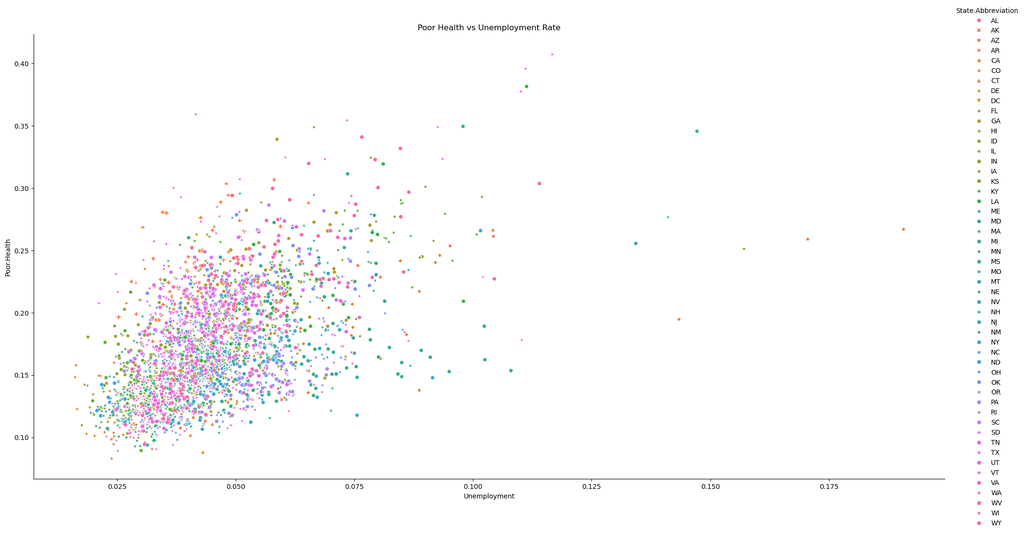

```python
# Unemployment rate
sns.relplot(x = "Unemployment", y = "Poor.Health", data=county_data, hue="State.Abbreviation", style="State.Abbreviation",
            height=10, aspect=2)
plt.title("Poor Health vs Unemployment Rate")
plt.show()
# interpretation: clear positive correlation
```

## 8.2 Excessive drinking as the only predictor

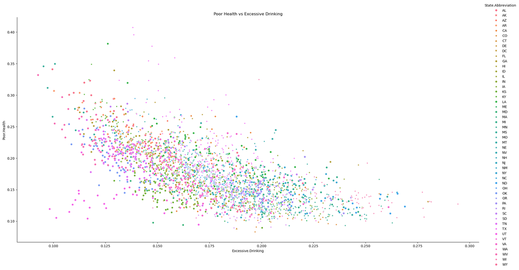

```python
# Excessive drinking
sns.relplot(x = "Excessive.Drinking", y = "Poor.Health", data=county_data, hue="State.Abbreviation", style="State.Abbreviation",
            height=10, aspect=2)
plt.title("Poor Health vs Excessive Drinking")
plt.show()
# interpretation: clear negative correlation with a decreasing absolute slope
```

## 8.3 Smoking proportion and uninsured rate as two predictors

- The scatterplot shows a strong positive relationship between smoking rates and poor health, with higher smoking prevalence associated with worse health outcomes.
- Counties with higher uninsured rates (indicated by different colors and markers) tend to cluster toward higher poor health values, suggesting an additional negative effect.
- Overall, the combined influence of smoking and lack of insurance appears to significantly contribute to poorer health outcomes.

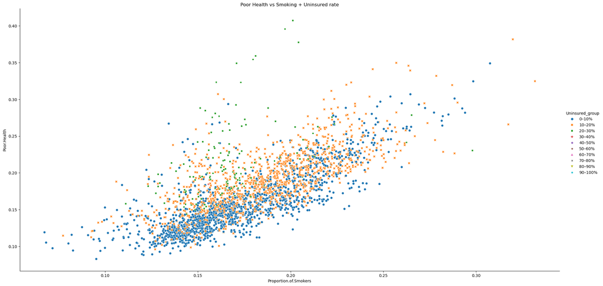

```python
# Smoking and the uninsured rate
county_data["Uninsured_group"] = pd.cut(county_data["Uninsured"], bins=[0,0.1,0.2,0.3,0.4,0.5,0.6,0.7,0.8,0.9,1.0],
    labels=["0–10%","10–20%","20–30%","30–40%","40–50%", "50–60%", "60–70%", "70–80%", "80–90%", "90–100%"],
    include_lowest=True)
sns.relplot(x = 'Proportion.of.Smokers', y='Poor.Health', data=county_data, hue="Uninsured_group", style="Uninsured_group",
            height=10, aspect=2)
plt.title("Poor Health vs Smoking + Uninsured rate")
plt.show()
# interpretation: clear upward correlation between the proportion of poor health and the proportion of smokers;
# The higher uninsured group has a higher proportion of poor health, given the proportion of smokers.
```

## 8.4 Primary care physicians per 1000 and the uninsured rate as two predictors

- The scatterplot suggests a negative relationship between the number of primary care physicians and poor health, with higher physician availability generally associated with better health outcomes.
- Counties with higher uninsured rates tend to have worse health outcomes, as indicated by their clustering at higher poor health values.
- Overall, both access to healthcare providers and insurance coverage appear to play important roles in improving population health.

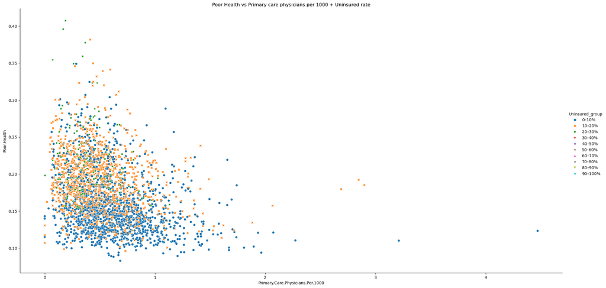

```python
# Primary care physicians per 1000 and the uninsured rate
sns.relplot(x = 'Primary.Care.Physicians.Per.1000', y='Poor.Health', data=county_data, hue="Uninsured_group", style="Uninsured_group",
            height=10, aspect=2)
plt.title("Poor Health vs Primary care physicians per 1000 + Uninsured rate")
plt.show()
# interpretation: there is a negative relationship between physician availability and poor health;
# Counties with higher uninsured rates tend to cluster at higher poor health levels
```

# 9 Decision Trees

Decision trees are useful for analyzing data because they can flexibly capture nonlinear relationships and interactions between predictors while remaining easy to interpret and visualize. In our case, we follow these metrics for all our trees:

- Maximum lead nodes are set to be 5
- Train-test split: to evaluate how well a model generalizes to new, unseen data by training it on one subset and testing its performance on another.
- Variable Importance metrics will be provided to rank the importance.
- We will construct 5 trees: 4 in accordance with our questions and the other one uses all predictors (a subset of predictors selected from our questions out of all).

```python
from sklearn import tree
from sklearn.tree import DecisionTreeRegressor, plot_tree
from sklearn.model_selection import train_test_split
from sklearn.metrics import mean_squared_error
```

## 9.1 Decision Tree with all the 5 predictors

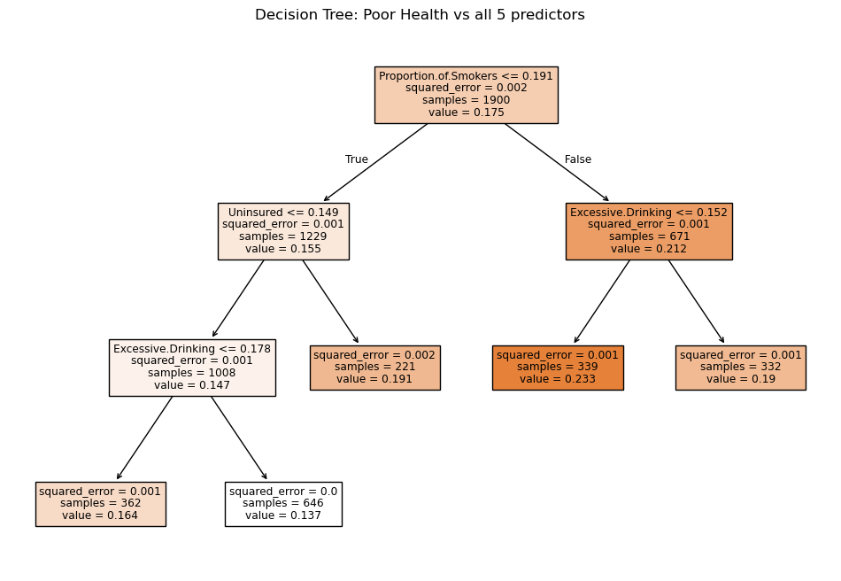

```python
y = county_data['Poor.Health']
results = []

X = county_data[["Proportion.of.Smokers","Uninsured","Primary.Care.Physicians.Per.1000","Excessive.Drinking","Unemployment"]]
X_train, X_test, y_train, y_test = train_test_split(X, y, test_size=0.3, random_state=526)
tree = DecisionTreeRegressor(max_leaf_nodes=5, random_state=526)
tree.fit(X_train, y_train)
plt.figure(figsize=(12,8))
plot_tree(tree, filled = True, feature_names = X.columns)
plt.title("Decision Tree: Poor Health vs all 5 predictors")
plt.show()
y_pred = tree.predict(X_test)
mse = mean_squared_error(y_test, y_pred)
results.append(["Full Tree", "All Predictors", mse])
```

## 9.2 Decision tree with only unemployment as the predictor

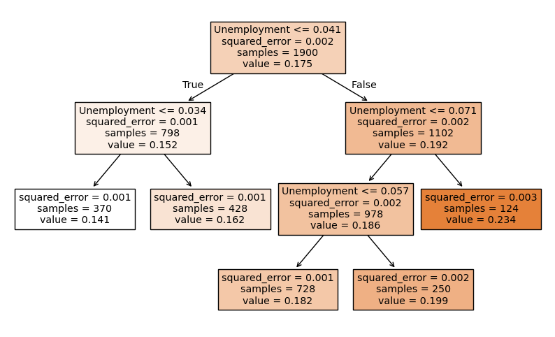

```python
# Unemployment rate
X1 = county_data[["Unemployment"]]
X1_train, X1_test, y_train, y_test = train_test_split(X1, y, test_size=0.3, random_state=526)
tree1 = DecisionTreeRegressor(max_leaf_nodes=5, random_state=526)
tree1.fit(X1_train, y_train)
plt.figure(figsize=(10,6))
plot_tree(tree1, feature_names=X1.columns, filled=True)
plt.show()
y_pred1 = tree1.predict(X1_test)
mse1 = mean_squared_error(y_test, y_pred1)
results.append(["Tree 1", "Unemployment", mse1])
```

- The decision tree shows that unemployment rate is a strong predictor of poor health, with higher unemployment associated with worse health outcomes and a clear stepwise (nonlinear) pattern across thresholds.
- The decreasing squared error across splits indicates that each division improves model fit, creating more homogeneous groups, while higher squared error in some terminal nodes suggests greater variability in poor health for certain unemployment ranges.
- Overall, the model highlights unemployment as a key driver of health disparities, though remaining variation (captured by squared error) implies that other factors also influence health outcomes.

## 9.3 Decision tree with only excessive drinking as the predictor

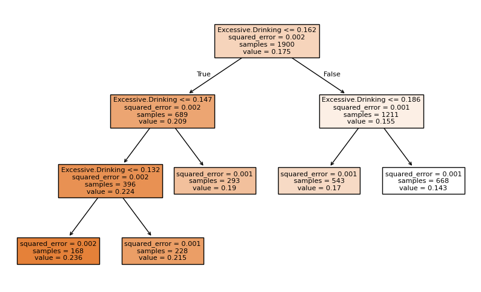

```python
# Excessive Drinking
X2 = county_data[["Excessive.Drinking"]]
X2_train, X2_test, y_train, y_test = train_test_split(X2, y, test_size=0.3, random_state=526)
tree2 = DecisionTreeRegressor(max_leaf_nodes=5, random_state=526)
tree2.fit(X2_train, y_train)
plt.figure(figsize=(10,6))
plot_tree(tree2, feature_names=X2.columns, filled=True)
plt.show()
y_pred2 = tree2.predict(X2_test)
mse2 = mean_squared_error(y_test, y_pred2)
results.append(["Tree 2", "Excessive Drinking", mse2])
```

## 9.4 Decision Tree with proportion of smokers and the uninsured rate as predictors

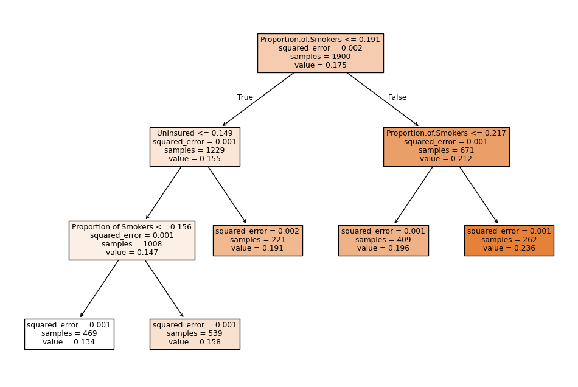

```python
# Proportion.of.Smokers + Uninsured
X3 = county_data[["Proportion.of.Smokers", "Uninsured"]]
X3_train, X3_test, y_train, y_test = train_test_split(X3, y, test_size=0.3, random_state=526)
tree3 = DecisionTreeRegressor(max_leaf_nodes=5, random_state=526)
tree3.fit(X3_train, y_train)
plt.figure(figsize=(12,8))
plot_tree(tree3, feature_names=X3.columns, filled=True)
plt.show()
y_pred3 = tree3.predict(X3_test)
mse3 = mean_squared_error(y_test, y_pred3)
results.append(["Tree 3", "Proportion.of.Smokers + Uninsured", mse3])
```

- The decision tree shows that smoking rate is the primary driver, with the first split on smokers indicating it has the strongest impact on poor health outcomes.
- Among counties with lower smoking rates, the uninsured rate further differentiates health, where higher uninsured levels are associated with worse outcomes, highlighting the role of healthcare access.
- The relatively low squared error values (around 0.001–0.002) suggest the model fits the data reasonably well, though higher error in some terminal nodes indicates remaining variability not explained by smoking and insurance alone.

## 9.5 Decision Tree withh primary care physicians per 1000 people and the uninsured rate as predictors

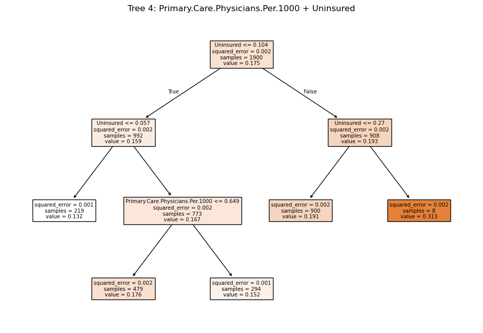

```python
# Primary.Care.Physicians.Per.1000 + Uninsured
X4 = county_data[["Primary.Care.Physicians.Per.1000", "Uninsured"]]
X4_train, X4_test, y_train, y_test = train_test_split(X4, y, test_size=0.3, random_state=526)
tree4 = DecisionTreeRegressor(max_leaf_nodes=5, random_state=526)
tree4.fit(X4_train, y_train)
plt.figure(figsize=(12,8))
plot_tree(tree4, feature_names=X4.columns, filled=True)
plt.title("Tree 4: Primary.Care.Physicians.Per.1000 + Uninsured")
plt.show()
y_pred4 = tree4.predict(X4_test)
mse4 = mean_squared_error(y_test, y_pred4)
results.append(["Tree 4", "Primary.Care.Physicians.Per.1000 + Uninsured", mse4])
```

- The decision tree shows that the uninsured rate is the most important predictor, as it appears at the root and drives the main splits, with higher uninsured levels associated with worse health outcomes.
- Among counties with lower uninsured rates, primary care physician availability further improves health, where more physicians per 1000 people correspond to better outcomes.
- The squared error decreases with splits (around 0.002 to 0.001 in some nodes), indicating improved model fit, though higher error in certain branches suggests remaining variability not fully explained by insurance and physician access alone.

## 9.6 Prediction accuracy of the decision tree models

```python
results_cd = pd.DataFrame(results, columns=["Tree", "Predictors", "Test MSE"])
print(results_cd)
```

```
        Tree                                    Predictors  Test MSE
0  Full Tree                                All Predictors  0.000800
1     Tree 1                                  Unemployment  0.001327
2     Tree 2                            Excessive Drinking  0.001099
3     Tree 3             Proportion.of.Smokers + Uninsured  0.000822
4     Tree 4  Primary.Care.Physicians.Per.1000 + Uninsured  0.001494
```

- The full model has the lowest test MSE, indicating the best predictive performance.
- The model using smoking and uninsured rates performs nearly as well, highlighting their strong importance.
- In contrast, models with only unemployment or physician access have higher errors, suggesting weaker predictive power.

## 9.7 Variable Importance Metrics

Now we can identify which predictors contribute most to the model’s predictions by measuring their relative influence on reducing error.

```python
# full model
importances = pd.DataFrame({'Feature':X_train.columns,
                            'Importance':np.round(tree.feature_importances_,3)})
importances = importances.sort_values('Importance',ascending=False)
print(importances[:5])

# Proportion.of.Smokers + Uninsured
importance3 = pd.Series(tree3.feature_importances_, index=X3.columns)
print(importance3)

# Primary.Care.Physicians.Per.1000 + Uninsured
importance4 = pd.Series(tree4.feature_importances_, index=X4.columns)
print(importance4)
```

```
                            Feature  Importance
0             Proportion.of.Smokers       0.628
3                Excessive.Drinking       0.215
1                         Uninsured       0.157
2  Primary.Care.Physicians.Per.1000       0.000
4                      Unemployment       0.000
Proportion.of.Smokers    0.837466
Uninsured                0.162534
dtype: float64
Primary.Care.Physicians.Per.1000    0.106361
Uninsured                           0.893639
dtype: float64
```

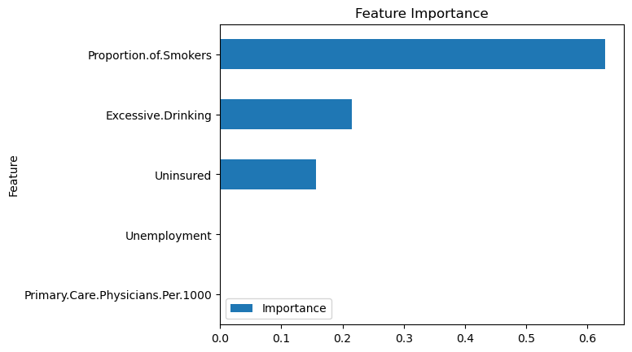

```python
importances.set_index('Feature').sort_values('Importance').plot(kind='barh')
plt.title('Feature Importance')
plt.show()
```

- The variable importance results show that smoking is the most influential predictor, followed by excessive drinking and uninsured rates, while physician availability and unemployment contribute little to the model.

# 10 Regression models

- Instead of decision trees, we can also fit data on regression models.
- Regression models estimate the linear relationship between predictors and the response variable.
- They provide interpretable coefficients, showing the direction and magnitude of each predictor’s effect.
- Regression assumes a specific functional form (e.g., linearity), which may be more restrictive than trees.
- However, they often offer simpler interpretation and easier inference compared to more flexible models.

```python
 import statsmodels.formula.api as smf
```

# 10.1 Regression models based on the four research questions

We will analyze the regression models through the elements in the summary, and below is an example of the summary:

```python
# Unemployment rate
olsmod1 = smf.ols(formula='Q("Poor.Health") ~ Unemployment', data=county_data)
olsres1 = olsmod1.fit()
print(olsres1.summary())
```

```
                            OLS Regression Results
==============================================================================
Dep. Variable:       Q("Poor.Health")   R-squared:                       0.296
Model:                            OLS   Adj. R-squared:                  0.296
Method:                 Least Squares   F-statistic:                     1142.
Date:                Tue, 17 Mar 2026   Prob (F-statistic):          2.57e-209
Time:                        19:40:18   Log-Likelihood:                 5034.0
No. Observations:                2715   AIC:                        -1.006e+04
Df Residuals:                    2713   BIC:                        -1.005e+04
Df Model:                           1
Covariance Type:            nonrobust
================================================================================
                   coef    std err          t      P>|t|      [0.025      0.975]
--------------------------------------------------------------------------------
Intercept        0.1009      0.002     44.009      0.000       0.096       0.105
Unemployment     1.5941      0.047     33.800      0.000       1.502       1.687
==============================================================================
Omnibus:                      127.077   Durbin-Watson:                   1.015
Prob(Omnibus):                  0.000   Jarque-Bera (JB):              151.158
Skew:                           0.507   Prob(JB):                     1.50e-33
Kurtosis:                       3.556   Cond. No.                         65.0
==============================================================================

Notes:
[1] Standard Errors assume that the covariance matrix of the errors is correctly specified.
```

```python
# Excessive drinking
olsmod2 = smf.ols(formula='Q("Poor.Health") ~ Q("Excessive.Drinking")', data=county_data)
olsres2 = olsmod2.fit()
print(olsres2.summary())
```

```
                            OLS Regression Results
==============================================================================
Dep. Variable:       Q("Poor.Health")   R-squared:                       0.436
Model:                            OLS   Adj. R-squared:                  0.436
Method:                 Least Squares   F-statistic:                     2100.
Date:                Tue, 17 Mar 2026   Prob (F-statistic):               0.00
Time:                        19:40:18   Log-Likelihood:                 5335.3
No. Observations:                2715   AIC:                        -1.067e+04
Df Residuals:                    2713   BIC:                        -1.065e+04
Df Model:                           1
Covariance Type:            nonrobust
===========================================================================================
                              coef    std err          t      P>|t|      [0.025      0.975]
-------------------------------------------------------------------------------------------
Intercept                   0.3379      0.004     93.179      0.000       0.331       0.345
Q("Excessive.Drinking")    -0.9347      0.020    -45.830      0.000      -0.975      -0.895
==============================================================================
Omnibus:                      285.596   Durbin-Watson:                   1.220
Prob(Omnibus):                  0.000   Jarque-Bera (JB):              761.323
Skew:                           0.584   Prob(JB):                    4.79e-166
Kurtosis:                       5.316   Cond. No.                         32.3
==============================================================================

Notes:
[1] Standard Errors assume that the covariance matrix of the errors is correctly specified.
```

```python
# Proportion.of.Smokers + Uninsured
olsmod3 = smf.ols(formula='Q("Poor.Health") ~ Q("Proportion.of.Smokers") + Uninsured', data=county_data)
olsres3 = olsmod3.fit()
print(olsres3.summary())
```

```
                            OLS Regression Results
==============================================================================
Dep. Variable:       Q("Poor.Health")   R-squared:                       0.655
Model:                            OLS   Adj. R-squared:                  0.654
Method:                 Least Squares   F-statistic:                     2569.
Date:                Tue, 17 Mar 2026   Prob (F-statistic):               0.00
Time:                        19:40:18   Log-Likelihood:                 5999.9
No. Observations:                2715   AIC:                        -1.199e+04
Df Residuals:                    2712   BIC:                        -1.198e+04
Df Model:                           2
Covariance Type:            nonrobust
==============================================================================================
                                 coef    std err          t      P>|t|      [0.025      0.975]
----------------------------------------------------------------------------------------------
Intercept                     -0.0194      0.003     -6.956      0.000      -0.025      -0.014
Q("Proportion.of.Smokers")     0.8789      0.015     59.380      0.000       0.850       0.908
Uninsured                      0.3442      0.011     32.019      0.000       0.323       0.365
==============================================================================
Omnibus:                      688.588   Durbin-Watson:                   1.151
Prob(Omnibus):                  0.000   Jarque-Bera (JB):             2167.935
Skew:                           1.274   Prob(JB):                         0.00
Kurtosis:                       6.559   Cond. No.                         30.3
==============================================================================

Notes:
[1] Standard Errors assume that the covariance matrix of the errors is correctly specified.
```

```python
# Primary.Care.Physicians.Per.1000 + Uninsured
olsmod4 = smf.ols(formula='Q("Poor.Health") ~ Q("Primary.Care.Physicians.Per.1000") + Uninsured', data=county_data)
olsres4 = olsmod4.fit()
print(olsres4.summary())
```

```
                            OLS Regression Results
==============================================================================
Dep. Variable:       Q("Poor.Health")   R-squared:                       0.246
Model:                            OLS   Adj. R-squared:                  0.246
Method:                 Least Squares   F-statistic:                     443.5
Date:                Tue, 17 Mar 2026   Prob (F-statistic):          2.28e-167
Time:                        19:40:18   Log-Likelihood:                 4941.1
No. Observations:                2715   AIC:                            -9876.
Df Residuals:                    2712   BIC:                            -9858.
Df Model:                           2
Covariance Type:            nonrobust
=========================================================================================================
                                            coef    std err          t      P>|t|      [0.025      0.975]
---------------------------------------------------------------------------------------------------------
Intercept                                 0.1494      0.003     58.742      0.000       0.144       0.154
Q("Primary.Care.Physicians.Per.1000")    -0.0286      0.002    -12.149      0.000      -0.033      -0.024
Uninsured                                 0.3801      0.016     23.428      0.000       0.348       0.412
==============================================================================
Omnibus:                      395.700   Durbin-Watson:                   1.075
Prob(Omnibus):                  0.000   Jarque-Bera (JB):              653.945
Skew:                           0.973   Prob(JB):                    9.94e-143
Kurtosis:                       4.413   Cond. No.                         25.3
==============================================================================

Notes:
[1] Standard Errors assume that the covariance matrix of the errors is correctly specified.
```

## 10.2 Summary from the regression models

- The regression results show that smoking has the strongest positive association with poor health, with a large and highly significant coefficient.
- Uninsured rate is also a strong positive predictor, consistently associated with worse health outcomes across models.
- Excessive drinking has a negative coefficient, suggesting a counterintuitive relationship, though it may reflect underlying confounding factors.
- Primary care physician availability has a negative effect, indicating that greater access to healthcare is linked to better health outcomes.
- The model combining smoking and uninsured rates achieves the highest explanatory power (R² ≈ 0.655), making it the most effective among the tested regression models.

# 11 Conclusions

# 12 Future directions

Now, we have the inference, we can make some suggestions for the government and the company: